# Polynomial Regression and Splines

### **Polynomial regression**

As you already saw during theoretical lecture, polynomial regression allows to model a non-linear relationship between the response and the covariates by adding a polynomial term into the linear regression model. It leverages the good properties of a standard linear regression models while introducing flexibility.

In this case, we can think that a good approximation can be obtained by adding 2-degree polynomial. Let’s check

```r
poly_lm <- lm(nox~poly(dis, 2), data=data_house)

summary(poly_lm)
```

```
##
## Call:
## lm(formula = nox ~ poly(dis, 2), data = data_house)
##
## Residuals:
##       Min        1Q    Median        3Q       Max
## -0.129559 -0.044514 -0.007753  0.025778  0.201882
##
## Coefficients:
##                Estimate Std. Error t value Pr(>|t|)
## (Intercept)    0.554695   0.002828  196.16   <2e-16 ***
## poly(dis, 2)1 -2.003096   0.063610  -31.49   <2e-16 ***
## poly(dis, 2)2  0.856330   0.063610   13.46   <2e-16 ***
## ---
## Signif. codes:  0 '***' 0.001 '**' 0.01 '*' 0.05 '.' 0.1 ' ' 1
##
## Residual standard error: 0.06361 on 503 degrees of freedom
## Multiple R-squared:  0.6999, Adjusted R-squared:  0.6987
## F-statistic: 586.4 on 2 and 503 DF,  p-value: < 2.2e-16
```

All the coefficients are significant at any $\alpha$ level (see previous exercise lecture - Multiple Regression Model - for values of lm output). The value of R2 is not bad. The estimated polynomal regression can be written as

$$\hat{nox} = 0.55 - 2 dis + 0.86
dis^2$$

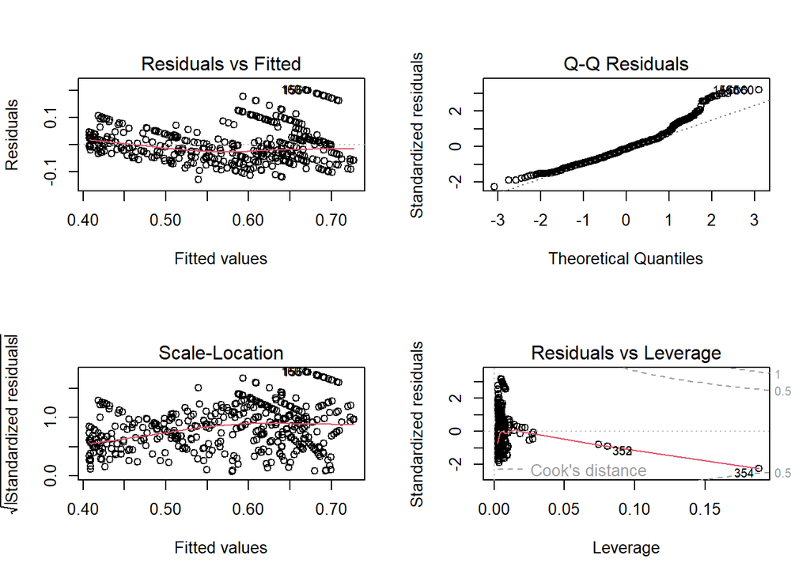

```r
par(mfrow=c(2,2))
plot(poly_lm)
```

Interpretation:

- Top-left: we can observe that there is a slight pattern –> probably increasing the degree of our polynomial regression we can solve the concern
- Top-right: it highlights a skewed distribution
- Bottom-left: it seems there is a slight issue of heteroskedasticity
- Bottom-right: no outlier, few leverage points but not influential.

Let’s try with 3-degree polynomial

```r
poly_lm_2 <- lm(nox~poly(dis, 3), data=data_house)

summary(poly_lm_2)
```

```
##
## Call:
## lm(formula = nox ~ poly(dis, 3), data = data_house)
##
## Residuals:
##       Min        1Q    Median        3Q       Max
## -0.121130 -0.040619 -0.009738  0.023385  0.194904
##
## Coefficients:
##                Estimate Std. Error t value Pr(>|t|)
## (Intercept)    0.554695   0.002759 201.021  < 2e-16 ***
## poly(dis, 3)1 -2.003096   0.062071 -32.271  < 2e-16 ***
## poly(dis, 3)2  0.856330   0.062071  13.796  < 2e-16 ***
## poly(dis, 3)3 -0.318049   0.062071  -5.124 4.27e-07 ***
## ---
## Signif. codes:  0 '***' 0.001 '**' 0.01 '*' 0.05 '.' 0.1 ' ' 1
##
## Residual standard error: 0.06207 on 502 degrees of freedom
## Multiple R-squared:  0.7148, Adjusted R-squared:  0.7131
## F-statistic: 419.3 on 3 and 502 DF,  p-value: < 2.2e-16
```

All the coefficients are still significant. The R2 is improved, thus this model seems to fit better data.

The estimated polynomal regression can be written as

$$\hat{nox} = 0.55 - 2 dis + 0.86 dis^2 -
0.32 dis^3$$

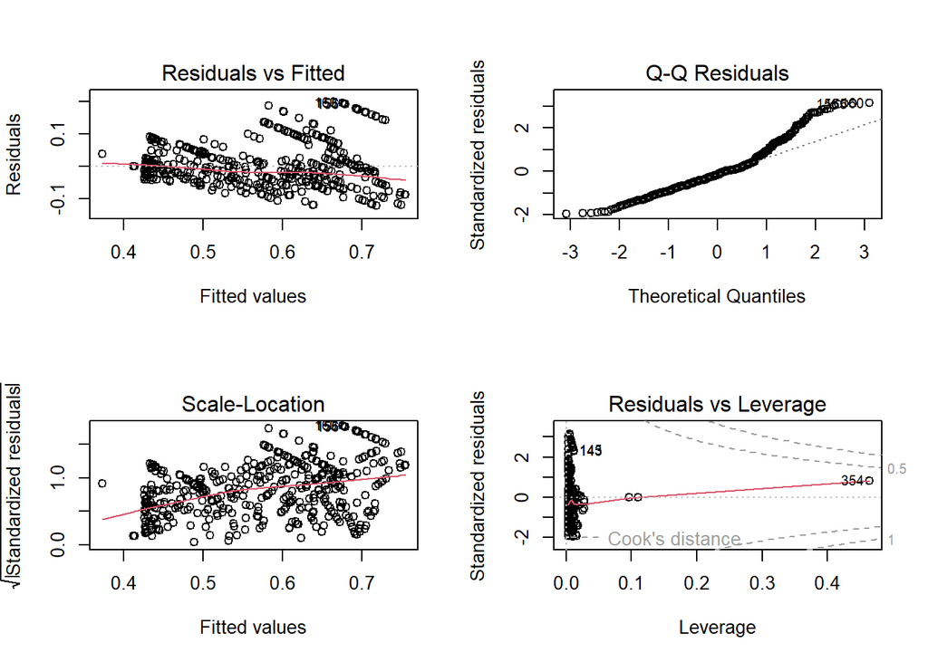

```r
par(mfrow=c(2,2))
plot(poly_lm_2)
```

Interpretation:

- Top-left: linearity improves
- Top-right: it highlights a skewed distribution
- Bottom-left: same as before
- Bottom-right: no outlier, few leverage points but not influential.

We can visualize our approximations below

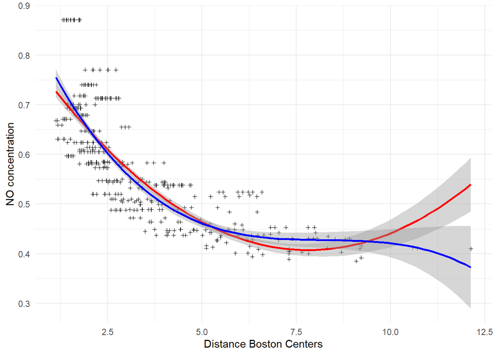

```r
ggplot(data_house, aes(x = dis, y = nox)) +
  geom_point(size = 1, shape=3) +
  geom_smooth(method = "lm", formula = y ~ poly(x, 2), color = "red") +  # Adds 1st regression line
  geom_smooth(method = "lm", formula = y ~ poly(x, 3), color = "blue") + # Adds 2nd regression line
  labs(
    x = "Distance Boston Centers",
    y = "NO concentration"
  ) +
  theme_minimal()
```

Also from a graphical point of view, the 3-degree polynomial seems to fit better the data.

### **Regression Spline**

Instead of polynomial regression, looking at the first plot it is reasonable that regression splines can be useful to obtain a good model for our data.

With regression spline we can obtain different estimation of our coefficients (thus different estimated linear regression lines or polynomial regression lines) for different range of the covariate values.

##### **Linear Splines**

Starting from linear splines, looking at the first plot we can identify, at least, three different regions of *dis*.

```r
mod_spline <- lm(nox ~ bs(dis , knots = c(3.75, 6.25), degree = 1), data = data_house)
summary(mod_spline)
```

```
##
## Call:
## lm(formula = nox ~ bs(dis, knots = c(3.75, 6.25), degree = 1),
##     data = data_house)
##
## Residuals:
##       Min        1Q    Median        3Q       Max
## -0.125959 -0.040053 -0.007492  0.023143  0.192961
##
## Coefficients:
##                                              Estimate Std. Error t value
## (Intercept)                                  0.737900   0.006699  110.16
## bs(dis, knots = c(3.75, 6.25), degree = 1)1 -0.246518   0.010960  -22.49
## bs(dis, knots = c(3.75, 6.25), degree = 1)2 -0.295460   0.009503  -31.09
## bs(dis, knots = c(3.75, 6.25), degree = 1)3 -0.351308   0.025840  -13.60
##                                             Pr(>|t|)
## (Intercept)                                   <2e-16 ***
## bs(dis, knots = c(3.75, 6.25), degree = 1)1   <2e-16 ***
## bs(dis, knots = c(3.75, 6.25), degree = 1)2   <2e-16 ***
## bs(dis, knots = c(3.75, 6.25), degree = 1)3   <2e-16 ***
## ---
## Signif. codes:  0 '***' 0.001 '**' 0.01 '*' 0.05 '.' 0.1 ' ' 1
##
## Residual standard error: 0.06159 on 502 degrees of freedom
## Multiple R-squared:  0.7192, Adjusted R-squared:  0.7175
## F-statistic: 428.6 on 3 and 502 DF,  p-value: < 2.2e-16
```

The estimated regression spline corresponds to

$$\hat{nox} = 0.7379 -0.2465 dis -0.2955
(dis - 3.75)_+ -0.3513 (dis - 6.25)_+$$

And breaking down for each region created by the two knots:

- $dis < 3.75$: $\hat{nox} = 0.7379 -0.2465 dis$
- $3.75 < dis < 6.25$: $\hat{nox} = 0.7379 -0.2465 dis -0.2955 (dis - 3.75) = (0.7379 + 1.1081) - (0.2465 + 0.2955) dis = 1.846 - 0.542 dis$
- $dis > 6.25$: $\hat{nox} = 0.7379 -0.2465 dis -0.2955 (dis - 3.75) -0.3513 (dis - 6.25) = (0.7379 + 1.1081 + 2.1956) - (0.2465 + 0.2955 + 0.3513) dis = 4.0416 - 0.8933 dis$

All the coefficient are significant. The R2 is better than the two polynomial regression we considered so far.

We can try to add a new knot while still considering linear splines.

```r
mod_spline_2 <- lm(nox ~ bs(dis , knots = c(2.5, 5, 7.5), degree = 1), data = data_house)
summary(mod_spline_2)
```

```
##
## Call:
## lm(formula = nox ~ bs(dis, knots = c(2.5, 5, 7.5), degree = 1),
##     data = data_house)
##
## Residuals:
##       Min        1Q    Median        3Q       Max
## -0.120941 -0.040160 -0.008586  0.020421  0.193477
##
## Coefficients:
##                                               Estimate Std. Error t value
## (Intercept)                                   0.750399   0.009815   76.45
## bs(dis, knots = c(2.5, 5, 7.5), degree = 1)1 -0.156953   0.013474  -11.65
## bs(dis, knots = c(2.5, 5, 7.5), degree = 1)2 -0.302257   0.011445  -26.41
## bs(dis, knots = c(2.5, 5, 7.5), degree = 1)3 -0.319901   0.014296  -22.38
## bs(dis, knots = c(2.5, 5, 7.5), degree = 1)4 -0.353630   0.033931  -10.42
##                                              Pr(>|t|)
## (Intercept)                                    <2e-16 ***
## bs(dis, knots = c(2.5, 5, 7.5), degree = 1)1   <2e-16 ***
## bs(dis, knots = c(2.5, 5, 7.5), degree = 1)2   <2e-16 ***
## bs(dis, knots = c(2.5, 5, 7.5), degree = 1)3   <2e-16 ***
## bs(dis, knots = c(2.5, 5, 7.5), degree = 1)4   <2e-16 ***
## ---
## Signif. codes:  0 '***' 0.001 '**' 0.01 '*' 0.05 '.' 0.1 ' ' 1
##
## Residual standard error: 0.06244 on 501 degrees of freedom
## Multiple R-squared:  0.712,  Adjusted R-squared:  0.7097
## F-statistic: 309.6 on 4 and 501 DF,  p-value: < 2.2e-16
```

In this case, the estimated regression spline can be written as

$$\hat{nox} = 0.7504 -0.157 dis -0.3023
(dis - 2.5)_+ -0.3199 (dis - 5)_+ -0.3536 (dis - 7.5)_+$$

- $dis < 2.5$: $\hat{nox} = 0.7504 -0.157 dis$
- $2.5 < dis < 5$: $\hat{nox} = 1.5062 - 0.4593 dis$
- $5 < dis < 7.5$: $\hat{nox} = 3.1057 - 0.7792 dis$
- $dis > 7.5$: $\hat{nox} = 5.7577 - 1.1328 dis$

All the coefficient are significant. The R2 is less than the previous model.

Let’s visualize these two regression lines with linear splines.

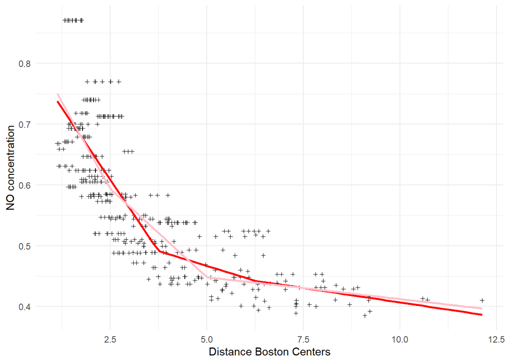

```r
ggplot(data_house, aes(x = dis, y = nox)) +
  geom_point(size = 1, shape=3) +
  geom_smooth(method = "lm", formula = y ~ bs(x , knots = c(3.75, 6.25), degree = 1), color = "red", se = FALSE) +  # Adds 1st regression line
  geom_smooth(method = "lm", formula = y ~ bs(x , knots = c(2.5, 5, 7.5), degree = 1), color = "pink", se = FALSE) + # Adds 2nd regression line
  labs(
    x = "Distance Boston Centers",
    y = "NO concentration"
  ) +
  theme_minimal()
```

##### **Cubic Splines**

Looking at the first plot, in this case it can make sense evaluating 1 or 2 knots.

Starting from the case of 1 knot, we can split the regions of *dis* with the knot=5.

```r
mod_spline_3 <- lm(nox ~ bs(dis , knots = c(5), degree = 3), data = data_house)
summary(mod_spline_3)
```

```
##
## Call:
## lm(formula = nox ~ bs(dis, knots = c(5), degree = 3), data = data_house)
##
## Residuals:
##      Min       1Q   Median       3Q      Max
## -0.12255 -0.04106 -0.01018  0.02345  0.19475
##
## Coefficients:
##                                    Estimate Std. Error t value Pr(>|t|)
## (Intercept)                         0.75801    0.01112  68.172  < 2e-16 ***
## bs(dis, knots = c(5), degree = 3)1 -0.18276    0.02236  -8.174 2.47e-15 ***
## bs(dis, knots = c(5), degree = 3)2 -0.39764    0.02444 -16.269  < 2e-16 ***
## bs(dis, knots = c(5), degree = 3)3 -0.30072    0.04095  -7.344 8.44e-13 ***
## bs(dis, knots = c(5), degree = 3)4 -0.37614    0.04856  -7.746 5.30e-14 ***
## ---
## Signif. codes:  0 '***' 0.001 '**' 0.01 '*' 0.05 '.' 0.1 ' ' 1
##
## Residual standard error: 0.06212 on 501 degrees of freedom
## Multiple R-squared:  0.7149, Adjusted R-squared:  0.7126
## F-statistic:   314 on 4 and 501 DF,  p-value: < 2.2e-16
```

The estimated regression spline corresponds to

$$\hat{nox} = 0.7580 -0.1828 dis - 0.3976
dis^2 - 0.3007 dis^3 - 0.3761 (dis - 5)^3_+$$

All the coefficient are significant at any $\alpha$ level. The R2 is still less than the first regression spline model but better than the previous one.

Looking at the first plot, it makes sense considering 2 knots as follows

```r
mod_spline_4 <- lm(nox ~ bs(dis , knots = c(3.75, 6.25), degree = 3), data = data_house)
summary(mod_spline_4)
```

```
##
## Call:
## lm(formula = nox ~ bs(dis, knots = c(3.75, 6.25), degree = 3),
##     data = data_house)
##
## Residuals:
##       Min        1Q    Median        3Q       Max
## -0.126507 -0.041125 -0.009091  0.024642  0.191858
##
## Coefficients:
##                                             Estimate Std. Error t value
## (Intercept)                                  0.73268    0.01387  52.813
## bs(dis, knots = c(3.75, 6.25), degree = 3)1 -0.06362    0.02521  -2.523
## bs(dis, knots = c(3.75, 6.25), degree = 3)2 -0.28476    0.01585 -17.971
## bs(dis, knots = c(3.75, 6.25), degree = 3)3 -0.26778    0.03162  -8.468
## bs(dis, knots = c(3.75, 6.25), degree = 3)4 -0.37955    0.04247  -8.937
## bs(dis, knots = c(3.75, 6.25), degree = 3)5 -0.29818    0.05556  -5.367
##                                             Pr(>|t|)
## (Intercept)                                  < 2e-16 ***
## bs(dis, knots = c(3.75, 6.25), degree = 3)1   0.0119 *
## bs(dis, knots = c(3.75, 6.25), degree = 3)2  < 2e-16 ***
## bs(dis, knots = c(3.75, 6.25), degree = 3)3 2.80e-16 ***
## bs(dis, knots = c(3.75, 6.25), degree = 3)4  < 2e-16 ***
## bs(dis, knots = c(3.75, 6.25), degree = 3)5 1.23e-07 ***
## ---
## Signif. codes:  0 '***' 0.001 '**' 0.01 '*' 0.05 '.' 0.1 ' ' 1
##
## Residual standard error: 0.06163 on 500 degrees of freedom
## Multiple R-squared:  0.7199, Adjusted R-squared:  0.7171
## F-statistic: 257.1 on 5 and 500 DF,  p-value: < 2.2e-16
```

The estimated regression spline corresponds to

$$\hat{nox} = 0.7327 -0.0636 dis - 0.2848
dis^2 - 0.2678 dis^3 - 0.3796 (dis - 3.75)^3_+ - 0.2982 (dis -
6.25)^3_+$$

In this case, all the coefficients are significant except the coefficient of *dis* that is significant at level of $\alpha$ greater than 0.01. We obtained the best R2 among all models.

Let’s visualize these two regression lines with cubic splines.

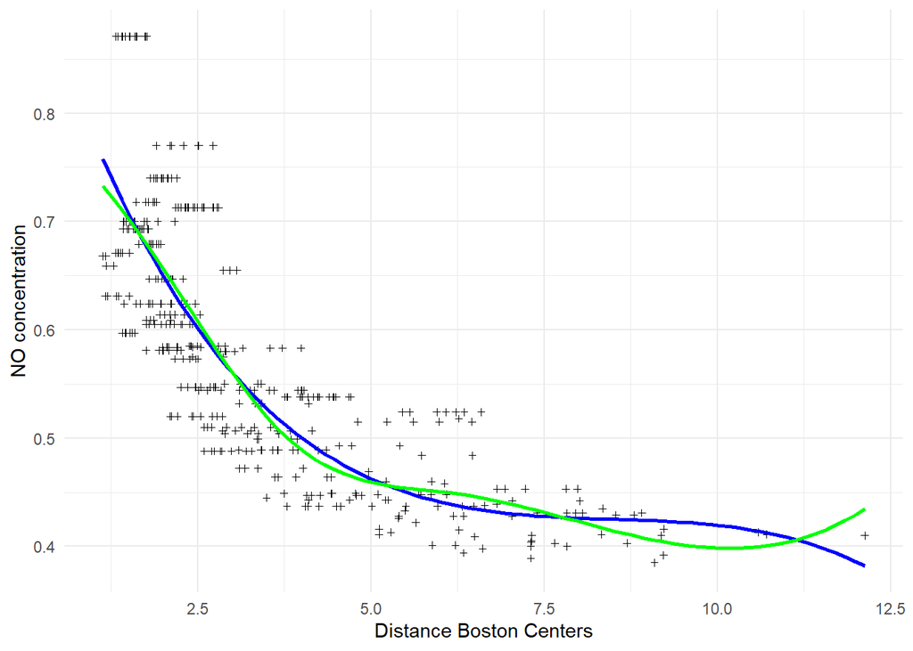

```r
ggplot(data_house, aes(x = dis, y = nox)) +
  geom_point(size = 1, shape=3) +
  geom_smooth(method = "lm", formula = y ~ bs(x , knots = c(5), degree = 3), color = "blue", se = FALSE) +  # Adds 1st regression line
  geom_smooth(method = "lm", formula = y ~ bs(x , , knots = c(3.75, 6.25), degree = 3), color = "green", se = FALSE) + # Adds 2nd regression line
  labs(
    x = "Distance Boston Centers",
    y = "NO concentration"
  ) +
  theme_minimal()
```

##### **Natural Splines**

Another interesting regression spline is the natural spline which require additional boundary constraints: the natural function is required to be linear at the boundary (see theoretical lecture - natural cubic spline).

```r
mod_nat_spline <- lm(nox ~ ns(dis , knots = c(3.75, 6.25)), data = data_house)
summary(mod_nat_spline)
```

```
##
## Call:
## lm(formula = nox ~ ns(dis, knots = c(3.75, 6.25)), data = data_house)
##
## Residuals:
##       Min        1Q    Median        3Q       Max
## -0.122882 -0.041436 -0.008163  0.022666  0.192838
##
## Coefficients:
##                                  Estimate Std. Error t value Pr(>|t|)
## (Intercept)                      0.746466   0.007402 100.847  < 2e-16 ***
## ns(dis, knots = c(3.75, 6.25))1 -0.214356   0.015388 -13.930  < 2e-16 ***
## ns(dis, knots = c(3.75, 6.25))2 -0.579692   0.026409 -21.950  < 2e-16 ***
## ns(dis, knots = c(3.75, 6.25))3 -0.217794   0.031659  -6.879  1.8e-11 ***
## ---
## Signif. codes:  0 '***' 0.001 '**' 0.01 '*' 0.05 '.' 0.1 ' ' 1
##
## Residual standard error: 0.06167 on 502 degrees of freedom
## Multiple R-squared:  0.7185, Adjusted R-squared:  0.7168
## F-statistic: 427.1 on 3 and 502 DF,  p-value: < 2.2e-16
```

The estimated regression spline corresponds to

$$\hat{nox} = 0.7464 -0.2144 dis - 0.5797
(dis - 3.75)^3_+ - 0.2178 (dis - 6.25)^3_+$$

All the coefficients are significant. The R2 is less than the twin cubic spline (w/o additional constraints). However, it can be also possible that the previous model overfit.

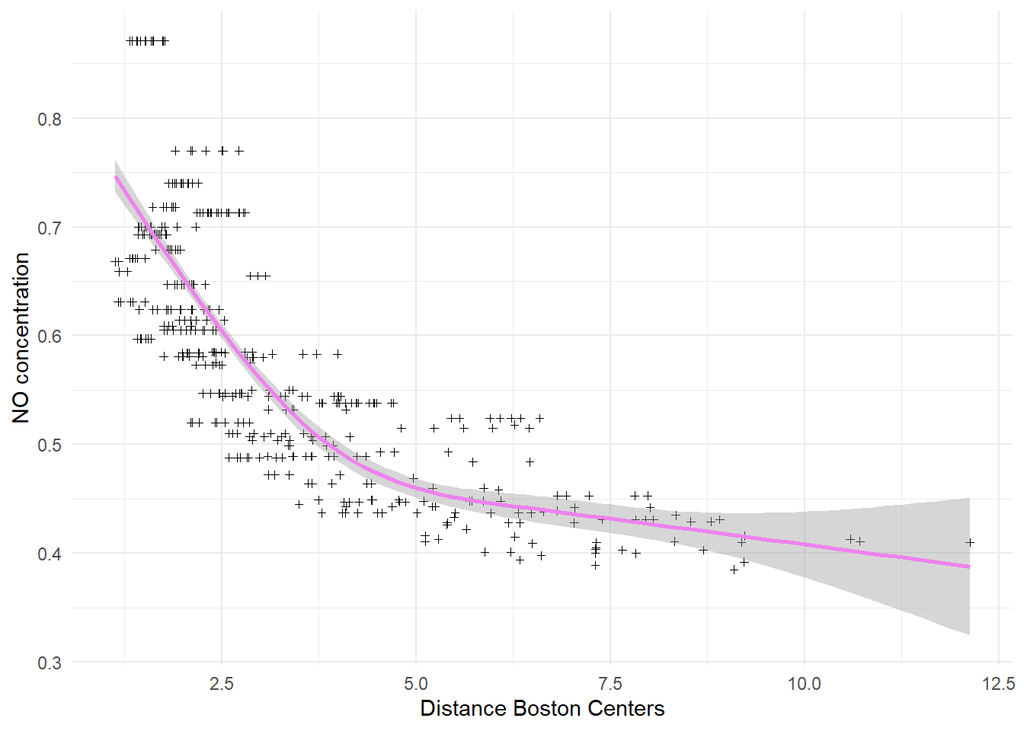

```r
ggplot(data_house, aes(x = dis, y = nox)) +
  geom_point(size = 1, shape=3) +
  geom_smooth(method = "lm", formula = y ~ ns(x, knots = c(3.75, 6.25)), color = "violet") +  # Adds regression line
  labs(
    x = "Distance Boston Centers",
    y = "NO concentration"
  ) +
  theme_minimal()
```

##### **Smoothing Splines**

Smoothing splines find a function of *dis* that fit well data while penalizing its variability. The importance of the latter is regulated by the tuning parameter $\lambda$ which controls the roughness of the smoothing spline (hence, the effective degree of freedom):

- when $\lambda$ increases from $0$ to $\infty$, the degree of freedom decreases from $506$ to $2$

If we try different value of degree of freedoms (df), we can show that increasing the value the function should fit better the data.

```r
mod_smooth_spline <- smooth.spline(data_house$dis, data_house$nox, df = 4)
data_house$pred <- predict(mod_smooth_spline, data_house$dis)$y
mod_smooth_spline$lambda
```

```
## [1] 0.05013323
```

```r
mod_smooth_spline_2 <- smooth.spline(data_house$dis, data_house$nox, df = 10)
data_house$pred_2 <- predict(mod_smooth_spline_2, data_house$dis)$y
mod_smooth_spline_2$lambda
```

```
## [1] 0.0006626825
```

```r
mod_smooth_spline_3 <- smooth.spline(data_house$dis, data_house$nox, df = 200)
data_house$pred_3 <- predict(mod_smooth_spline_3, data_house$dis)$y
mod_smooth_spline_3$lambda
```

```
## [1] 6.992648e-22
```

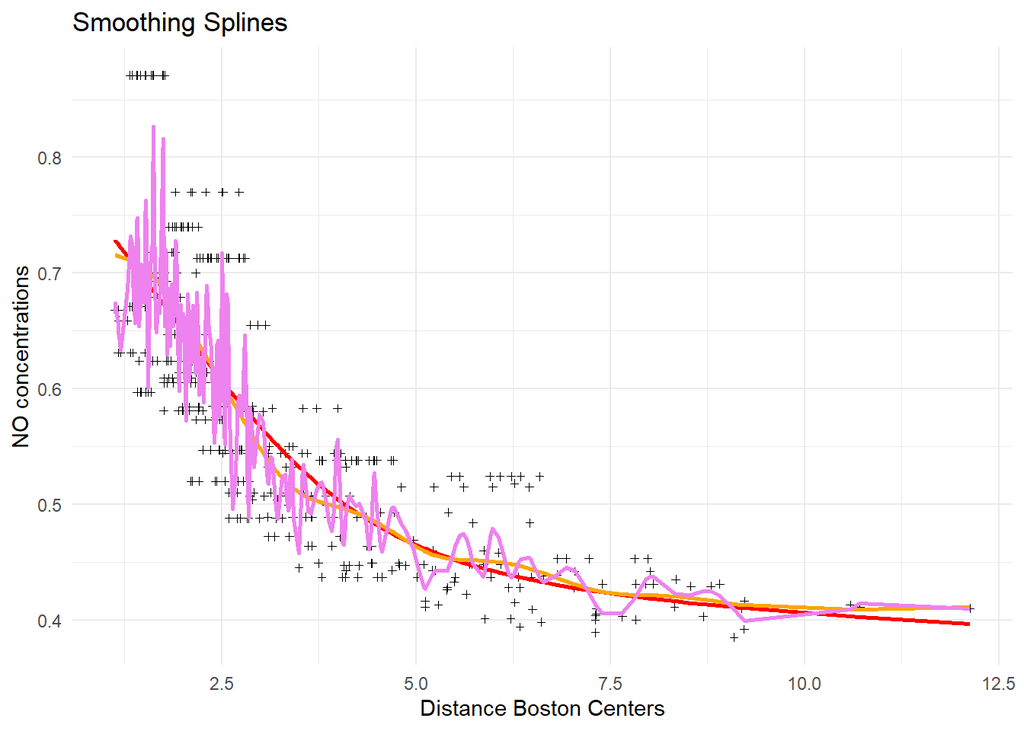

```r
ggplot(data_house, aes(y=nox, x=dis)) + geom_point(size = 1, shape=3) + geom_line(aes(y = pred), color = "red", linewidth = 1) + geom_line(aes(y = pred_2), color = "orange", linewidth = 1) + geom_line(aes(y = pred_3), color = "violet", linewidth = 1) +
  labs(title = "Smoothing Splines", x = "Distance Boston Centers", y = "NO concentrations")+
  theme_minimal()
```

From the plot, we can observe that the function related to df=4 and df=10 are more smooth than the function with df=200.

```r
mod_smooth_spline_cv <- smooth.spline(data_house$dis, data_house$nox, cv=TRUE)
data_house$pred_cv <- predict(mod_smooth_spline_cv, data_house$dis)$y
mod_smooth_spline_cv$lambda
```

```
## [1] 9.029534e-05
```

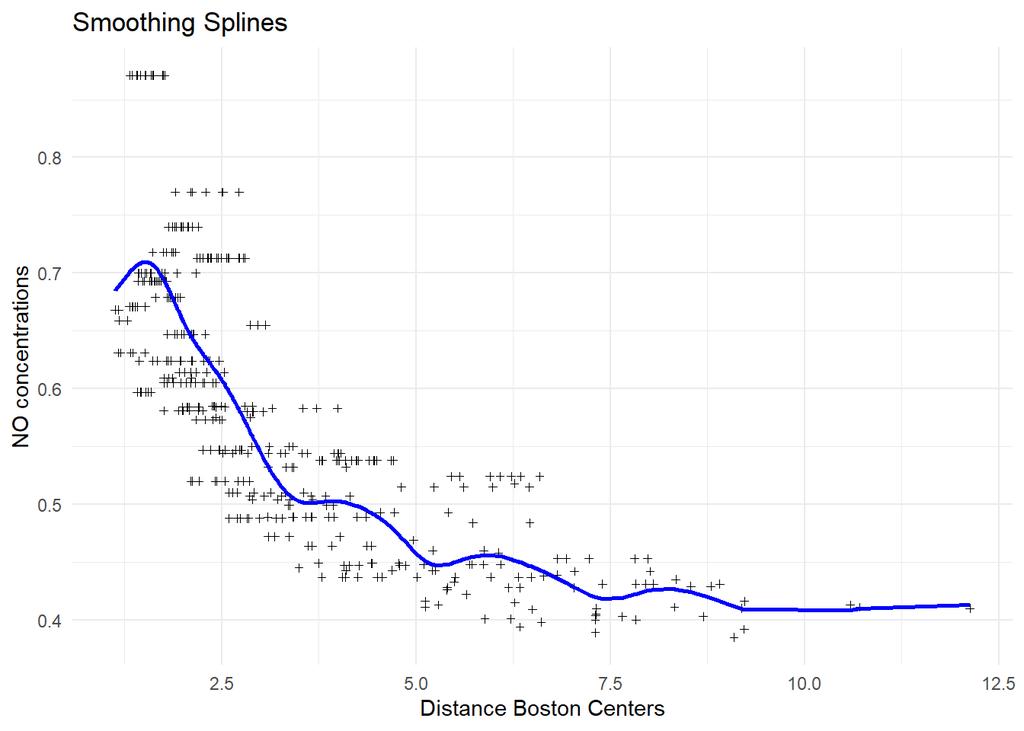

```r
ggplot(data_house, aes(y=nox, x=dis)) + geom_point(size = 1, shape=3) + geom_line(aes(y = pred_cv), color = "blue", linewidth = 1) +
  labs(title = "Smoothing Splines", x = "Distance Boston Centers", y = "NO concentrations")+
  theme_minimal()
```

The value of $\lambda$ is greater than the last model, indeed the plot shows a smooth function which try to interpolate better data than df=4 and df=10.